# Heart_disease_analysis

# here we will explore negative oldpeak rows

```python
round(sum(df['oldpeak'] < 0) / len(df) * 100, 1)
```

```
1.1
```

```python
df['oldpeak'].describe()
```

```
count    1190.000000
mean        0.922773
std         1.086337
min        -2.600000
25%         0.000000
50%         0.600000
75%         1.600000
max         6.200000
Name: oldpeak, dtype: float64
```

```python
df[df < 0] = 0.6
```

# machine learning model

```python
from sklearn.model_selection import train_test_split

# Set a variable X to the features of the dataframe and y to the target column.
X = df.drop('target', axis=1)
y = df['target']

# Split the data into training and testing sets.
X_train, X_test, y_train, y_test = train_test_split(X, y, test_size=0.30, random_state=101)
```

# random forest classifier

We will: Fit random forest models with a range of tree numbers and evaluate the out-of-bag error for each of these models. Plot the resulting out-of-bag errors as a function of the number of trees.

max_features m the number of features to consider when looking for the best split.

If we have M features, a popular method to determine m is to use the square root of M:

m=floor(M−−√)

```python
M_features=X.shape[1]
max_features=round(np.sqrt(M_features))-1
max_features
```

```
3
```

```python
from sklearn.ensemble import RandomForestClassifier

# Initialize the random forest estimator
# Note that the number of trees is not setup here
RF = RandomForestClassifier(oob_score=True,
                            random_state=42,
                            warm_start=True,
                            n_jobs=-1,
                            max_features=max_features)

oob_list = list()

# Iterate through all of the possibilities for
# number of trees
for n_trees in [15, 30, 50, 100, 150, 200, 300, 400, 500, 600]:

    # Use this to set the number of trees
    RF.set_params(n_estimators=n_trees)

    # Fit the model
    RF.fit(X_train, y_train)

    # Get the oob error
    oob_error = 1 - RF.oob_score_

    # Store it
    oob_list.append(pd.Series({'n_trees': n_trees, 'oob': oob_error}))

rf_oob_df = pd.concat(oob_list, axis=1).T.set_index('n_trees')

rf_oob_df
```

| n_trees | oob |
| --- | --- |
| 15.0 | 0.127251 |
| 30.0 | 0.109244 |
| 50.0 | 0.106843 |
| 100.0 | 0.087635 |
| 150.0 | 0.090036 |
| 200.0 | 0.092437 |
| 300.0 | 0.090036 |
| 400.0 | 0.093637 |
| 500.0 | 0.090036 |
| 600.0 | 0.090036 |

The out-of-bag error looks like stabilized around 150 trees.

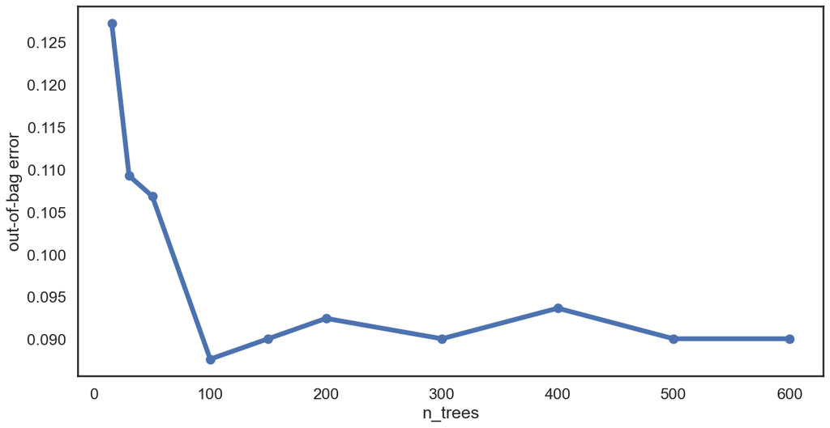

```python
sns.set_context('talk')
sns.set_style('white')

ax = rf_oob_df.plot(legend=False, marker='o', figsize=(14, 7), linewidth=5)
ax.set(ylabel='out-of-bag error');
```

# extra trees classifier

Repeat the process but this time using extra randomized trees (ExtraTreesClassifier). Note that the bootstrap parameter will have to be set to True for this model. Compare the out-of-bag errors for the two different types of models.

```python
from sklearn.ensemble import ExtraTreesClassifier

# Initialize the random forest estimator
# Note that the number of trees is not setup here
EF = ExtraTreesClassifier(oob_score=True,
                          random_state=42,
                          warm_start=True,
                          bootstrap=True,
                          n_jobs=-1)

oob_list = list()

# Iterate through all of the possibilities for
# number of trees
for n_trees in [15, 30, 50, 100, 150, 200, 300, 400, 500, 600]:

    # Use this to set the number of trees
    EF.set_params(n_estimators=n_trees)
    EF.fit(X_train, y_train)

    # oob error
    oob_error = 1 - EF.oob_score_
    oob_list.append(pd.Series({'n_trees': n_trees, 'oob': oob_error}))

et_oob_df = pd.concat(oob_list, axis=1).T.set_index('n_trees')

et_oob_df
```

| n_trees | oob |
| --- | --- |
| 15.0 | 0.130852 |
| 30.0 | 0.109244 |
| 50.0 | 0.097239 |
| 100.0 | 0.097239 |
| 150.0 | 0.098439 |
| 200.0 | 0.097239 |
| 300.0 | 0.099640 |
| 400.0 | 0.097239 |
| 500.0 | 0.097239 |
| 600.0 | 0.093637 |